# Anteproyecto - Filtro

### Scatterplots interpretation

#### Scatterplot of hours of sleep per day and GPA.

###### In this scatterplot, there most of the students that has good average grade (8.5-9.4) sleeps between 6 and 8 hours. But students with more than 9.5 average grade sleeps 8 hours.

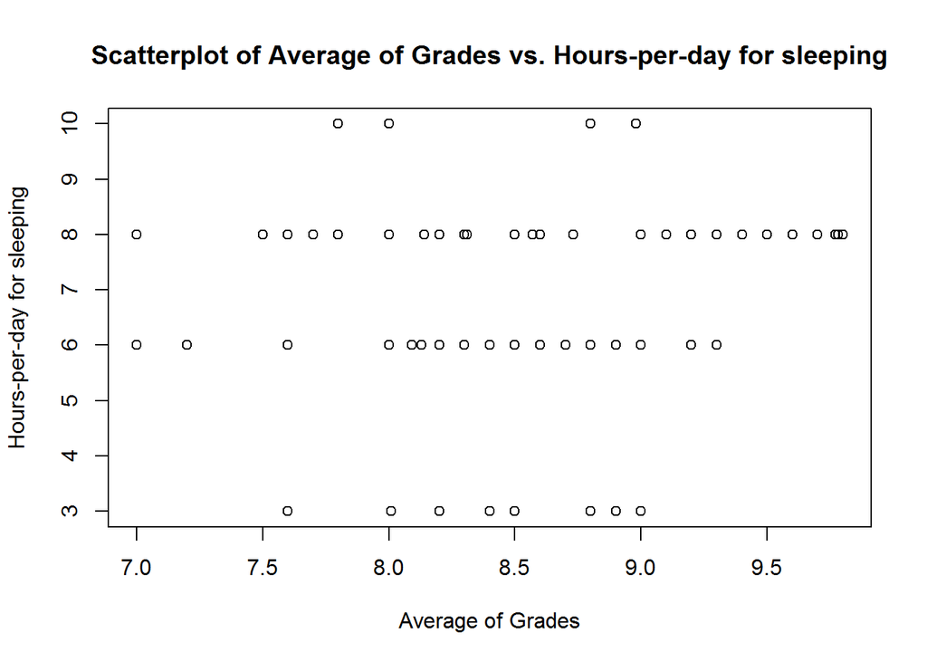

```r
plot( x = dsuaz$promedio, y = dsuaz$hrs_dormir_dia,
      main = "Scatterplot of Average of Grades vs. Hours-per-day for sleeping",
      xlab = "Average of Grades", ylab = "Hours-per-day for sleeping")
```

#### Scatterplot of hours of study per day and hours at university.

###### In this scatterplot, it shows that students with that studies in extra time 4 hours, normally they go to unversity 6 -8 hours.

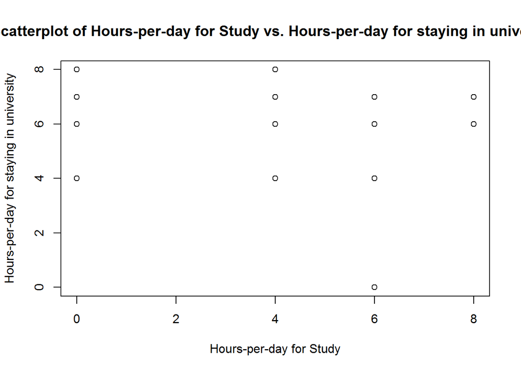

```r
plot( x = dsuaz$hrs_estudio_dia, y = dsuaz$hrs_universidad_dia,
      main = "Scatterplot of Hours-per-day for Study vs. Hours-per-day for staying in university",
      xlab = "Hours-per-day for Study", ylab = "Hours-per-day for staying in university")
```

#### Scatterplot on the passion that students have over their career and difficulty of the career.

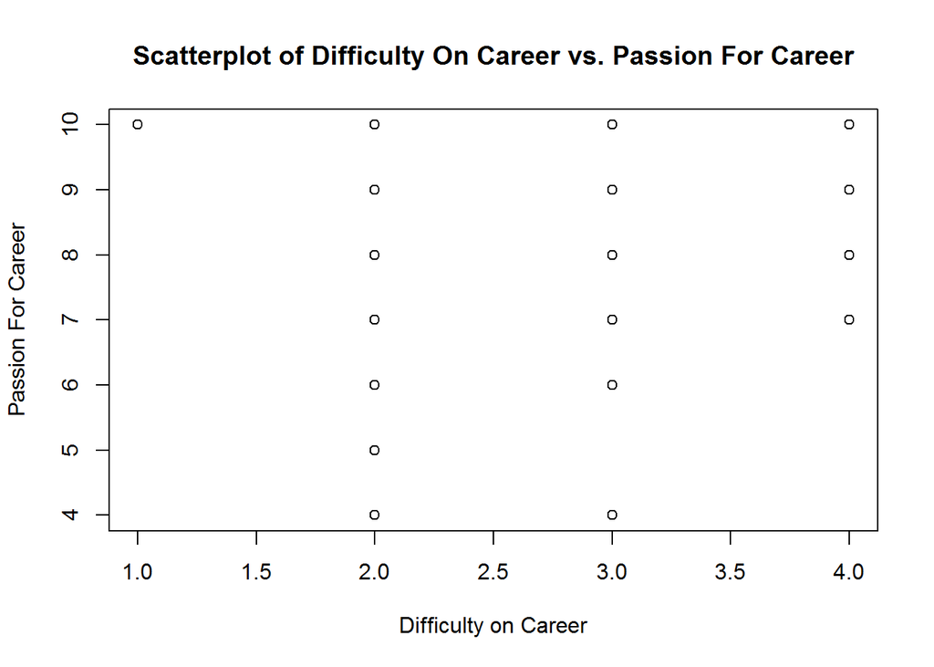

```r
plot( x = dsuaz$dificultad_licenciatura, y = dsuaz$pasion_licenciatura,
      main = "Scatterplot of Difficulty On Career vs. Passion For Career",
      xlab = "Difficulty on Career", ylab = "Passion For Career")
```

#### Scatterplot of GPA and hours for social activity oer day.

###### In this scatterplos shows that there is not a strong relation between this factor, in average many students has 3-4 hours of social activity per day.

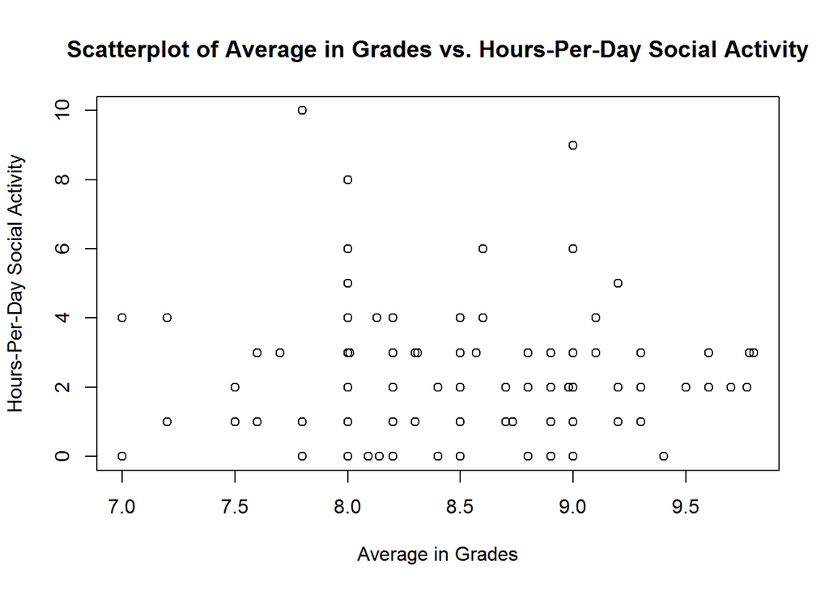

```r
plot( x = dsuaz$promedio, y = dsuaz$hrs_actsocial_dia,
      main = "Scatterplot of Average in Grades vs. Hours-Per-Day Social Activity",
      xlab = "Average in Grades", ylab = "Hours-Per-Day Social Activity")
```

### Correlations

#### Correlation between GPA and hours of social activity.

```r
sprintf("Coeficiente de Correlaci?n: %f", cor(dsuaz$promedio, dsuaz$hrs_actsocial_dia, use="pairwise.complete.obs"))
```

```
## [1] "Coeficiente de Correlaci?n: 0.049147"
```

#### Correlation between difficulty and passion over their career.

```r
sprintf("Coeficiente de Correlaci?n: %f", cor(dsuaz$dificultad_licenciatura, dsuaz$pasion_licenciatura, use="pairwise.complete.obs"))
```

```
## [1] "Coeficiente de Correlaci?n: 0.050797"
```

#### Correlation between hours of study per day and passion over their career.

```r
sprintf("Coeficiente de Correlaci?n: %f", cor(dsuaz$hrs_estudio_dia, dsuaz$pasion_licenciatura, use="pairwise.complete.obs"))
```

```
## [1] "Coeficiente de Correlaci?n: 0.327390"
```

#### Correlation between hours of study per day and GPA.

###### In this correlation we cofirm that there is a few relation within the data, almost is 0

```r
sprintf("Coeficiente de Correlaci?n: %f", cor(dsuaz$hrs_estudio_dia, dsuaz$promedio, use="pairwise.complete.obs"))
```

```
## [1] "Coeficiente de Correlaci?n: 0.152540"
```

### Parte 2- KNN- Formulas to Normalize

```r
# Funcion para Normalizar por min-max
minmax <- function(x) (
  return (( x - min(x)) / (max(x) - min(x)))
  )


# Funcion para Normalizar por z-Score
zscore <- function(x) (
  return (x - mean(x) / (sd(x)))
  )
```

### 2? Section

### —————————–

### - KNN- Normalization

```r
dsuaz$Ssalario_estimado <- factor(dsuaz$Ssalario_estimado)


dsuaz$Ssalario_estimado <- as.numeric(dsuaz$Ssalario_estimado);

# 1- Laborar 2- Posgrada
dsuaz$planes_egreso <- factor(dsuaz$planes_egreso)

dsuaz$planes_egreso <- as.numeric(dsuaz$planes_egreso)

# 1- Hombre 2- Mujer
dsuaz$genero <- factor(dsuaz$genero)

dsuaz$genero <- as.numeric(dsuaz$genero)

dsuaz$licenciatura <- factor(dsuaz$licenciatura)

dsuaz_n <- as.data.frame(sapply(dsuaz[,c(3,5,8,13,17)], minmax))
dsuaz_zs <- as.data.frame(sapply(dsuaz[,c(3,5,8,13,17)], zscore))
```

### Which feature were selected and why

### Hours per day spent playing video games

###### This was signficant feature to analyze, because

###### it remarks the extra- time that they have.

###### This is “leiusre time”, with this we can ensure if the career

###### requires of extra- time in homeworks, projects, academic research

###### but this was an initial view, when we saw the data we understand

###### that there is a relation that is more representative in

###### students form TIC careers (Informatics, Software, Science of Computer) play videogames,

###### this will enourage the estimation for the career “Engineer of Software”,

###### more hours is more probably is related to that career.

### Hours per day spent on the University

###### In this feature we saw a lot of variance according of the career,

###### the range is about 6 - 8 hours, but there is a relation between the career,

###### and its very common se that the increase of this hours is related from student of Medicine,

###### if we put this feature in order from high values to low, we saw that the careers have a force

###### relation, and of course this will encourage the estimation for the career “Medicine” in a theroy way.

### Hours per day spent for sleep

###### This feature was really interesant in the moment of analyze also it has a dependecy on the careers,

###### it decreases in students of Medicin and Engineer of Software,

###### of course there are the exceptions but this is in the point of the majority view,

###### that why this factor was selected.

### Difficulty on carrer

###### In terms of 1 -4 levels -in 1 is super easy, 2 normal, 3 hard, 4 very hard-,

###### this factor for us is one of the most important becase it remarks,

###### the complexity of differents careers, also this is so personal for each students,

###### but if we analyze well the data it has dependecies form the carreer,

###### if we order this factor we will se in first Medicine,

###### (Farmaceutic biochemist & Engineer Software in the same level) and in the last Psicology,

###### so there is a strong relation between them and a important factor for calssifying predictions.

## Hours in a workday (in their careers)

###### The range in this data is from 8 to 13, this is a factor from a personal

###### opinion or without having so few information, but in a simple view it has

###### a lot of dependecy in fact of the career is according to the hours in workday, studentes

###### in Engineer Software has few hours than Medicin student.

### Compute Distances

#### In this scenario, we calculated knn with manhattan distance with a value of k of 17, and the algorythm get 17 correct answers over 23, that is almost same result than the knn with euclidian distance.

```r
dsuaz_train <- dsuaz_n[1:90,]
dsuaz_testing <- dsuaz_n[91:113,]
dsuaz_train_labels <- dsuaz[1:90,21]
dsuaz_testing_labels <- dsuaz[91:113,21]


library(knnGarden)
library(gmodels)
resultsMH <- knnVCN(dsuaz_train,dsuaz_train_labels,dsuaz_testing, K = 17, ShowObs = FALSE,method = "manhattan",p =2)
resultsMH
```

```
##                     TstXIBelong
## 1                    Psicologia
## 2        Ingenieria de Software
## 3               Medicina Humana
## 4               Medicina Humana
## 5                    Psicologia
## 6                    Psicologia
## 7        Ingenieria de Software
## 8                    Psicologia
## 9        Ingenieria de Software
## 10 Quimico Farmaceutico Biologo
## 11       Ingenieria de Software
## 12              Medicina Humana
## 13                   Psicologia
## 14              Medicina Humana
## 15       Ingenieria de Software
## 16                   Psicologia
## 17              Medicina Humana
## 18                   Psicologia
## 19       Ingenieria de Software
## 20                   Psicologia
## 21                   Psicologia
## 22                   Psicologia
## 23 Quimico Farmaceutico Biologo
```

```r
dsuaz_testing_labels
```

```
##  [1] Ingenieria de Software       Quimico Farmaceutico Biologo
##  [3] Medicina Humana              Medicina Humana
##  [5] Psicologia                   Psicologia
##  [7] Ingenieria de Software       Quimico Farmaceutico Biologo
##  [9] Medicina Humana              Quimico Farmaceutico Biologo
## [11] Ingenieria de Software       Medicina Humana
## [13] Psicologia                   Medicina Humana
## [15] Ingenieria de Software       Psicologia
## [17] Quimico Farmaceutico Biologo Psicologia
## [19] Ingenieria de Software       Psicologia
## [21] Ingenieria de Software       Psicologia
## [23] Quimico Farmaceutico Biologo
## 4 Levels: Ingenieria de Software Medicina Humana ... Quimico Farmaceutico Biologo
```

### Training and Testing set

#### Count of persons in each career

```r
dsuaz_train_labels <- dsuaz[1:90,21]
dsuaz_testing_labels <- dsuaz[91:113,21]
table(dsuaz_train_labels)
```

```
## dsuaz_train_labels
##       Ingenieria de Software              Medicina Humana
##                           27                           25
##                   Psicologia Quimico Farmaceutico Biologo
##                           18                           20
```

```r
table(dsuaz_testing_labels)
```

```
## dsuaz_testing_labels
##       Ingenieria de Software              Medicina Humana
##                            6                            5
##                   Psicologia Quimico Farmaceutico Biologo
##                            7                            5
```

#### Min Max Normalization

```r
dsuaz_train <- dsuaz_n[1:90,]
dsuaz_testing <- dsuaz_n[91:113,]

dim(dsuaz_train)
```

```
## [1] 90  5
```

```r
dim(dsuaz_testing)
```

```
## [1] 23  5
```

#### Z-score Normalization

```r
dsuaz_train_zs <- dsuaz_zs[1:90,]
dsuaz_testing_zs <- dsuaz_zs[91:113,]

dim(dsuaz_train_zs)
```

```
## [1] 90  5
```

```r
dim(dsuaz_testing_zs)
```

```
## [1] 23  5
```

### KNN classification outputs

#### Min Max Normalization

```r
library(class)
library(gmodels)
dsuaz_results <- knn(train = dsuaz_train,test = dsuaz_testing,cl = dsuaz_train_labels, k = 1)

CrossTable(x = dsuaz_testing_labels,
            y = dsuaz_results,
            prop.chisq = FALSE)
```

```
##
##
##    Cell Contents
## |-------------------------|
## |                       N |
## |           N / Row Total |
## |           N / Col Total |
## |         N / Table Total |
## |-------------------------|
##
##
## Total Observations in Table:  23
##
##
##                              | dsuaz_results
##         dsuaz_testing_labels |       Ingenieria de Software |              Medicina Humana |                   Psicologia | Quimico Farmaceutico Biologo |                    Row Total |
## -----------------------------|------------------------------|------------------------------|------------------------------|------------------------------|------------------------------|
##       Ingenieria de Software |                            3 |                            0 |                            3 |                            0 |                            6 |
##                              |                        0.500 |                        0.000 |                        0.500 |                        0.000 |                        0.261 |
##                              |                        1.000 |                        0.000 |                        0.429 |                        0.000 |                              |
##                              |                        0.130 |                        0.000 |                        0.130 |                        0.000 |                              |
## -----------------------------|------------------------------|------------------------------|------------------------------|------------------------------|------------------------------|
##              Medicina Humana |                            0 |                            5 |                            0 |                            0 |                            5 |
##                              |                        0.000 |                        1.000 |                        0.000 |                        0.000 |                        0.217 |
##                              |                        0.000 |                        0.500 |                        0.000 |                        0.000 |                              |
##                              |                        0.000 |                        0.217 |                        0.000 |                        0.000 |                              |
## -----------------------------|------------------------------|------------------------------|------------------------------|------------------------------|------------------------------|
##                   Psicologia |                            0 |                            2 |                            4 |                            1 |                            7 |
##                              |                        0.000 |                        0.286 |                        0.571 |                        0.143 |                        0.304 |
##                              |                        0.000 |                        0.200 |                        0.571 |                        0.333 |                              |
##                              |                        0.000 |                        0.087 |                        0.174 |                        0.043 |                              |
## -----------------------------|------------------------------|------------------------------|------------------------------|------------------------------|------------------------------|
## Quimico Farmaceutico Biologo |                            0 |                            3 |                            0 |                            2 |                            5 |
##                              |                        0.000 |                        0.600 |                        0.000 |                        0.400 |                        0.217 |
##                              |                        0.000 |                        0.300 |                        0.000 |                        0.667 |                              |
##                              |                        0.000 |                        0.130 |                        0.000 |                        0.087 |                              |
## -----------------------------|------------------------------|------------------------------|------------------------------|------------------------------|------------------------------|
##                 Column Total |                            3 |                           10 |                            7 |                            3 |                           23 |
##                              |                        0.130 |                        0.435 |                        0.304 |                        0.130 |                              |
## -----------------------------|------------------------------|------------------------------|------------------------------|------------------------------|------------------------------|
##
##
```

#### Z-score Normalization

```r
 library(class)
 library(gmodels)
 dsuaz_results_zs <- knn(train = dsuaz_train_zs,test = dsuaz_testing_zs,cl = dsuaz_train_labels, k = 1)

 CrossTable(x = dsuaz_testing_labels,
             y = dsuaz_results_zs,
             prop.chisq = FALSE)
```

```
##
##
##    Cell Contents
## |-------------------------|
## |                       N |
## |           N / Row Total |
## |           N / Col Total |
## |         N / Table Total |
## |-------------------------|
##
##
## Total Observations in Table:  23
##
##
##                              | dsuaz_results_zs
##         dsuaz_testing_labels |       Ingenieria de Software |              Medicina Humana |                   Psicologia | Quimico Farmaceutico Biologo |                    Row Total |
## -----------------------------|------------------------------|------------------------------|------------------------------|------------------------------|------------------------------|
##       Ingenieria de Software |                            3 |                            0 |                            3 |                            0 |                            6 |
##                              |                        0.500 |                        0.000 |                        0.500 |                        0.000 |                        0.261 |
##                              |                        1.000 |                        0.000 |                        0.429 |                        0.000 |                              |
##                              |                        0.130 |                        0.000 |                        0.130 |                        0.000 |                              |
## -----------------------------|------------------------------|------------------------------|------------------------------|------------------------------|------------------------------|
##              Medicina Humana |                            0 |                            5 |                            0 |                            0 |                            5 |
##                              |                        0.000 |                        1.000 |                        0.000 |                        0.000 |                        0.217 |
##                              |                        0.000 |                        0.714 |                        0.000 |                        0.000 |                              |
##                              |                        0.000 |                        0.217 |                        0.000 |                        0.000 |                              |
## -----------------------------|------------------------------|------------------------------|------------------------------|------------------------------|------------------------------|
##                   Psicologia |                            0 |                            0 |                            4 |                            3 |                            7 |
##                              |                        0.000 |                        0.000 |                        0.571 |                        0.429 |                        0.304 |
##                              |                        0.000 |                        0.000 |                        0.571 |                        0.500 |                              |
##                              |                        0.000 |                        0.000 |                        0.174 |                        0.130 |                              |
## -----------------------------|------------------------------|------------------------------|------------------------------|------------------------------|------------------------------|
## Quimico Farmaceutico Biologo |                            0 |                            2 |                            0 |                            3 |                            5 |
##                              |                        0.000 |                        0.400 |                        0.000 |                        0.600 |                        0.217 |
##                              |                        0.000 |                        0.286 |                        0.000 |                        0.500 |                              |
##                              |                        0.000 |                        0.087 |                        0.000 |                        0.130 |                              |
## -----------------------------|------------------------------|------------------------------|------------------------------|------------------------------|------------------------------|
##                 Column Total |                            3 |                            7 |                            7 |                            6 |                           23 |
##                              |                        0.130 |                        0.304 |                        0.304 |                        0.261 |                              |
## -----------------------------|------------------------------|------------------------------|------------------------------|------------------------------|------------------------------|
##
##
```

### Determine the optimal K

#### Min Max Normalization

[figure not shown]

#### Z-score Normalization

[figure not shown]

### Frequency table and interpretation

#### Min Max Normalization

```r
library(class)
library(gmodels)
dsuaz_results <- knn(train = dsuaz_train,test = dsuaz_testing,cl = dsuaz_train_labels, k = 20)

CrossTable(x = dsuaz_testing_labels,
            y = dsuaz_results,
            prop.chisq = FALSE)
```

```
##
##
##    Cell Contents
## |-------------------------|
## |                       N |
## |           N / Row Total |
## |           N / Col Total |
## |         N / Table Total |
## |-------------------------|
##
##
## Total Observations in Table:  23
##
##
##                              | dsuaz_results
##         dsuaz_testing_labels |       Ingenieria de Software |              Medicina Humana |                   Psicologia | Quimico Farmaceutico Biologo |                    Row Total |
## -----------------------------|------------------------------|------------------------------|------------------------------|------------------------------|------------------------------|
##       Ingenieria de Software |                            4 |                            0 |                            1 |                            1 |                            6 |
##                              |                        0.667 |                        0.000 |                        0.167 |                        0.167 |                        0.261 |
##                              |                        0.667 |                        0.000 |                        0.333 |                        0.111 |                              |
##                              |                        0.174 |                        0.000 |                        0.043 |                        0.043 |                              |
## -----------------------------|------------------------------|------------------------------|------------------------------|------------------------------|------------------------------|
##              Medicina Humana |                            1 |                            4 |                            0 |                            0 |                            5 |
##                              |                        0.200 |                        0.800 |                        0.000 |                        0.000 |                        0.217 |
##                              |                        0.167 |                        0.800 |                        0.000 |                        0.000 |                              |
##                              |                        0.043 |                        0.174 |                        0.000 |                        0.000 |                              |
## -----------------------------|------------------------------|------------------------------|------------------------------|------------------------------|------------------------------|
##                   Psicologia |                            0 |                            0 |                            2 |                            5 |                            7 |
##                              |                        0.000 |                        0.000 |                        0.286 |                        0.714 |                        0.304 |
##                              |                        0.000 |                        0.000 |                        0.667 |                        0.556 |                              |
##                              |                        0.000 |                        0.000 |                        0.087 |                        0.217 |                              |
## -----------------------------|------------------------------|------------------------------|------------------------------|------------------------------|------------------------------|
## Quimico Farmaceutico Biologo |                            1 |                            1 |                            0 |                            3 |                            5 |
##                              |                        0.200 |                        0.200 |                        0.000 |                        0.600 |                        0.217 |
##                              |                        0.167 |                        0.200 |                        0.000 |                        0.333 |                              |
##                              |                        0.043 |                        0.043 |                        0.000 |                        0.130 |                              |
## -----------------------------|------------------------------|------------------------------|------------------------------|------------------------------|------------------------------|
##                 Column Total |                            6 |                            5 |                            3 |                            9 |                           23 |
##                              |                        0.261 |                        0.217 |                        0.130 |                        0.391 |                              |
## -----------------------------|------------------------------|------------------------------|------------------------------|------------------------------|------------------------------|
##
##
```

#### Z-score Normalization

```r
 library(class)
 library(gmodels)
 dsuaz_results_zs <- knn(train = dsuaz_train_zs,test = dsuaz_testing_zs,cl = dsuaz_train_labels, k = 10)

 CrossTable(x = dsuaz_testing_labels,
             y = dsuaz_results_zs,
             prop.chisq = FALSE)
```

```
##
##
##    Cell Contents
## |-------------------------|
## |                       N |
## |           N / Row Total |
## |           N / Col Total |
## |         N / Table Total |
## |-------------------------|
##
##
## Total Observations in Table:  23
##
##
##                              | dsuaz_results_zs
##         dsuaz_testing_labels |       Ingenieria de Software |              Medicina Humana |                   Psicologia | Quimico Farmaceutico Biologo |                    Row Total |
## -----------------------------|------------------------------|------------------------------|------------------------------|------------------------------|------------------------------|
##       Ingenieria de Software |                            4 |                            0 |                            2 |                            0 |                            6 |
##                              |                        0.667 |                        0.000 |                        0.333 |                        0.000 |                        0.261 |
##                              |                        0.571 |                        0.000 |                        0.222 |                        0.000 |                              |
##                              |                        0.174 |                        0.000 |                        0.087 |                        0.000 |                              |
## -----------------------------|------------------------------|------------------------------|------------------------------|------------------------------|------------------------------|
##              Medicina Humana |                            2 |                            3 |                            0 |                            0 |                            5 |
##                              |                        0.400 |                        0.600 |                        0.000 |                        0.000 |                        0.217 |
##                              |                        0.286 |                        0.750 |                        0.000 |                        0.000 |                              |
##                              |                        0.087 |                        0.130 |                        0.000 |                        0.000 |                              |
## -----------------------------|------------------------------|------------------------------|------------------------------|------------------------------|------------------------------|
##                   Psicologia |                            0 |                            0 |                            7 |                            0 |                            7 |
##                              |                        0.000 |                        0.000 |                        1.000 |                        0.000 |                        0.304 |
##                              |                        0.000 |                        0.000 |                        0.778 |                        0.000 |                              |
##                              |                        0.000 |                        0.000 |                        0.304 |                        0.000 |                              |
## -----------------------------|------------------------------|------------------------------|------------------------------|------------------------------|------------------------------|
## Quimico Farmaceutico Biologo |                            1 |                            1 |                            0 |                            3 |                            5 |
##                              |                        0.200 |                        0.200 |                        0.000 |                        0.600 |                        0.217 |
##                              |                        0.143 |                        0.250 |                        0.000 |                        1.000 |                              |
##                              |                        0.043 |                        0.043 |                        0.000 |                        0.130 |                              |
## -----------------------------|------------------------------|------------------------------|------------------------------|------------------------------|------------------------------|
##                 Column Total |                            7 |                            4 |                            9 |                            3 |                           23 |
##                              |                        0.304 |                        0.174 |                        0.391 |                        0.130 |                              |
## -----------------------------|------------------------------|------------------------------|------------------------------|------------------------------|------------------------------|
##
##
```